# InVivoStat Equivalence Test Analysis

## Response and equivalence bound

The Resp7 response is currently being analysed by the Equivalence (TOST) test Analysis module.The response has been arcsine transformed prior to analysis.

The lower equivalence bound is defined as -0.30. As only a lower bound has been defined a one-sided equivalence test has been performed.

## Scatterplot of the observed data (on the arcsine scale)

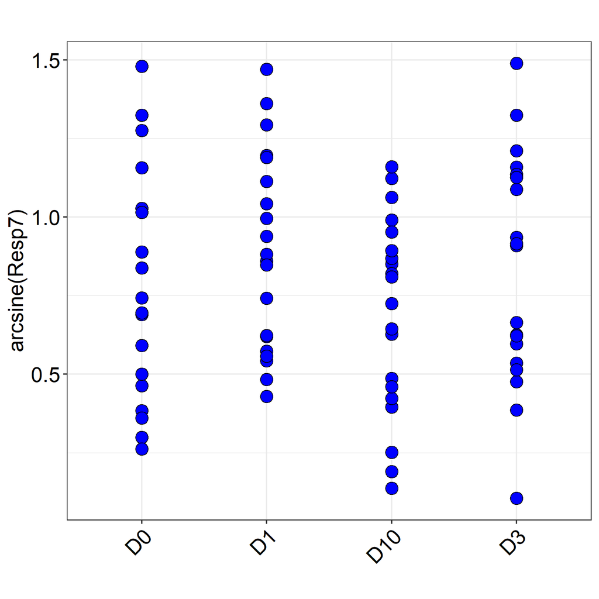

Tip: Use this plot to identify possible outliers.

## Model coefficients

|  | Estimate | Std. Error | t-value | p-value |
| --- | --- | --- | --- | --- |
| (Intercept) | 0.7939 | 0.0386 | 20.58 | < 0.0001 |
| Treat11 | -0.0165 | 0.0686 | -0.24 | 0.8108 |
| Treat12 | 0.0940 | 0.0662 | 1.42 | 0.1599 |
| Treat13 | -0.1003 | 0.0662 | -1.52 | 0.1340 |

## Table of the least square (predicted) means with 95% confidence intervals

| Mean ID | Treat1 | Mean | Lower 95% CI | Upper 95% CI |
| --- | --- | --- | --- | --- |
| 1 | D0 | 0.777 | 0.618 | 0.937 |
| 2 | D1 | 0.888 | 0.736 | 1.040 |
| 3 | D10 | 0.694 | 0.542 | 0.845 |
| 4 | D3 | 0.817 | 0.665 | 0.968 |

## Plot of the least square (predicted) means with 95% confidence intervals

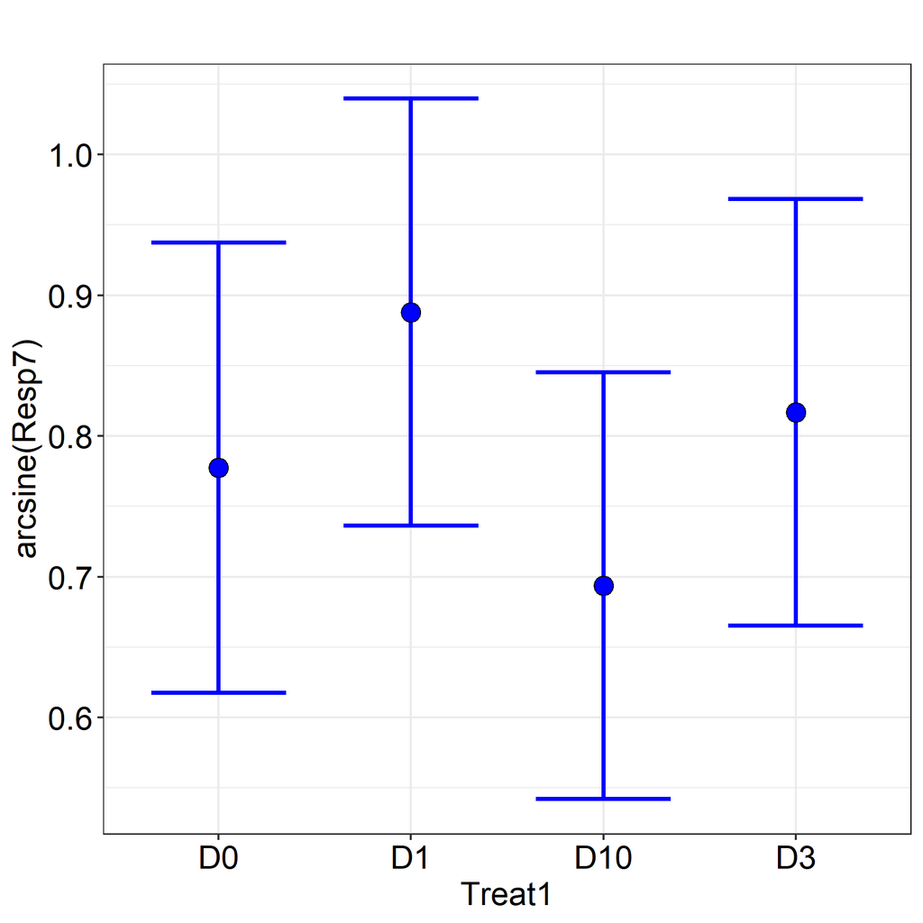

## All to one pairwise equivalence assessments

| Comparison | Difference | Lower one-sided 95% CI | Lower equivalence bound | Equivalence assessment |
| --- | --- | --- | --- | --- |
| D0 - D1 | -0.111 | -0.295 | -0.3 | Equivalent |
| D10 - D1 | -0.194 | -0.374 | -0.3 | Inconclusive |
| D3 - D1 | -0.071 | -0.251 | -0.3 | Equivalent |

## Plot of the comparisons between the predicted means with 95% one-sided confidence interval along with equivalence bound

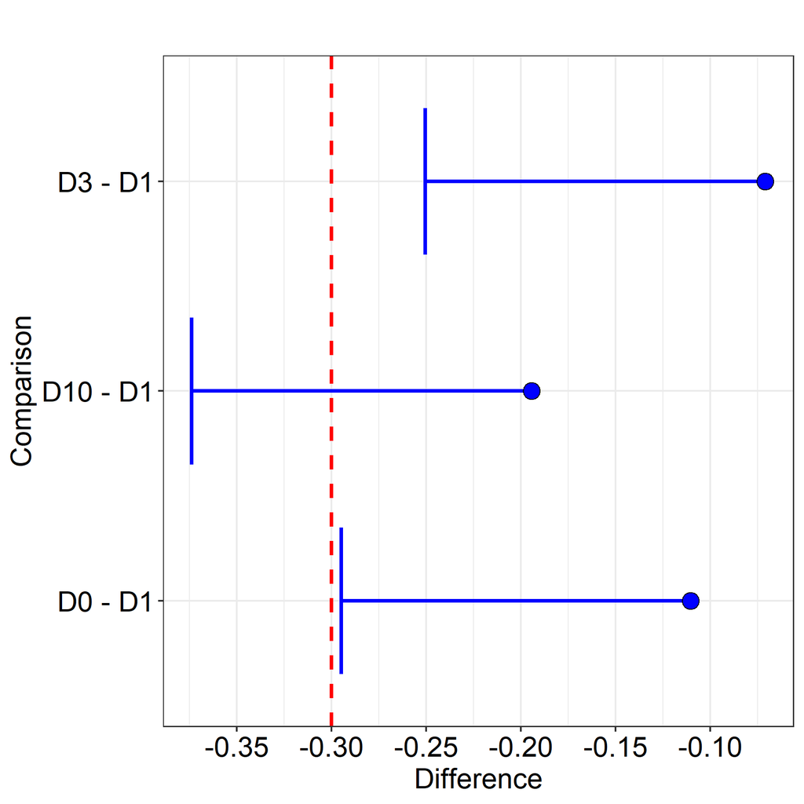

## Conclusion

Conclusion: The following means are deemed equivalent at the 5% level: D0 and D1, D3 and D1.

## Diagnostic plot

### Residuals vs. predicted plot

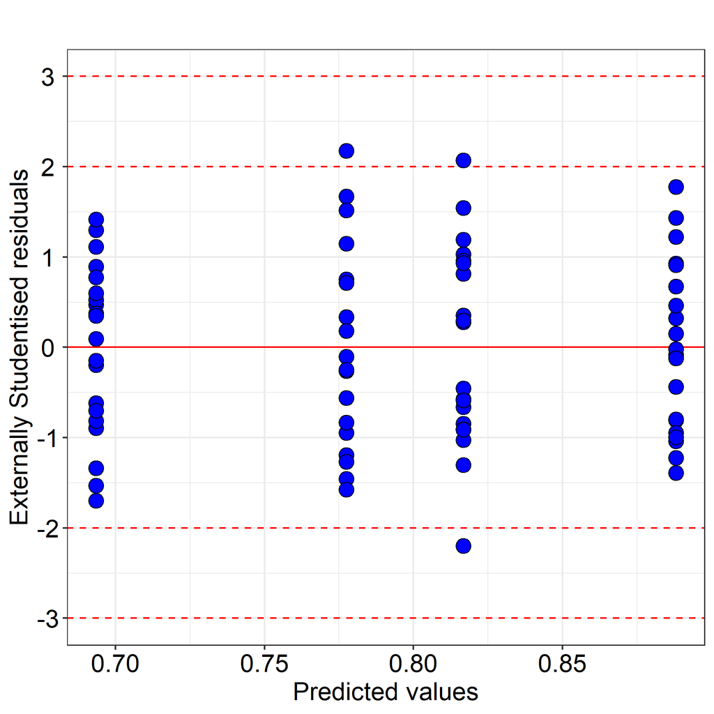

Tip: On this plot look to see if the spread of the points increases as the predicted values increase. If so the response may need transforming.

Tip: Any observation with a residual less than -3 or greater than 3 (SD) should be investigated as a possible outlier.

## Analysis description

The data were analysed using a one-sided equivalence test, see Limentani et al. 2005, with Treat1 as the treatment factor. The response was arcsine transformed prior to analysis to stabilise the variance.

For more information on the theoretical approaches that are implemented within this module, see Bate and Clark (2014).

## References

When referring to InVivoStat, please cite 'InVivoStat, version 5.2.0'.

Bate, S.T. and Clark, R.A. (2014). The Design and Statistical Analysis of Animal Experiments. Cambridge University Press.

Limentani, G.B., Ringo, M.C., Ye, F., Bergquist, M.L. and MCSorley E.O. (2005). Beyond the t-test: Statistical equivalence testing. Analytical Chemistry, 77(11), 221-226.